# MACHINE LEARNING PRACTICE

# MODEL

```r
# start with my model
names(newdata)
```

```
## [1] "classe"        "accelaration1" "acceleration2"
```

```r
table(newdata$classe)
```

```
##
##    A    B    C    D    E
## 5580 3797 3422 3216 3607
```

```r
# create my training and test sets

datos <- createDataPartition(y = newdata$classe,
                             p = 0.7, list = FALSE)
training <- newdata[datos,]
testing  <- newdata[-datos,]
dim(training); dim(testing)
```

```
## [1] 13737     3
```

```
## [1] 5885    3
```

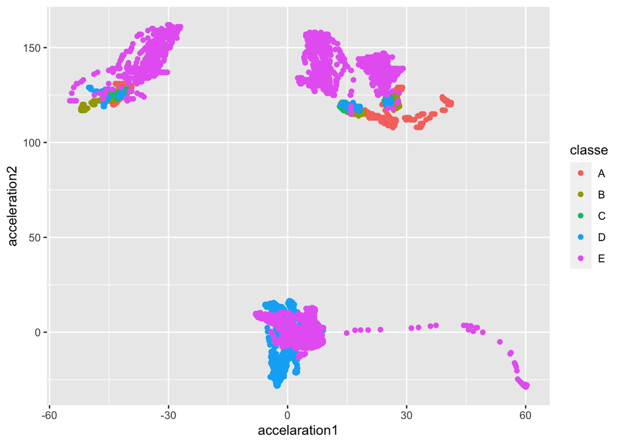

```r
qplot(accelaration1, acceleration2, colour=classe, data = training)
```

```r
# training the model

entrEmod <- train(classe ~ ., method = "rpart", data = training)
print(entrEmod$finalModel)
```

```
## n= 13737
##
## node), split, n, loss, yval, (yprob)
##       * denotes terminal node
##
## 1) root 13737 9831 A (0.28 0.19 0.17 0.16 0.18)
##   2) acceleration2< 130.5 12592 8695 A (0.31 0.21 0.19 0.18 0.11)
##     4) acceleration2>=-0.615 11985 8101 A (0.32 0.22 0.2 0.17 0.085) *
##     5) acceleration2< -0.615 607  242 E (0.021 0.012 0 0.37 0.6) *
##   3) acceleration2>=130.5 1145    9 E (0.0079 0 0 0 0.99) *
```

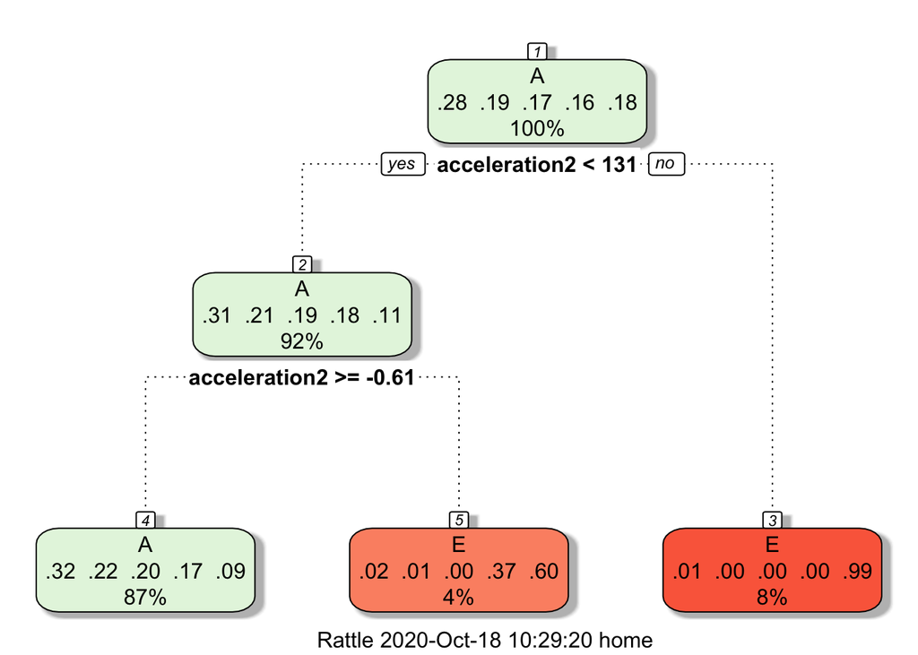

```r
# graphing the model
fancyRpartPlot(entrEmod$finalModel)
```

# POINT FOUR

### HOW TO USE CROSS VALIDATION

for cross validation i decided to use k-flod method and use my training data for this process so i split my dataset into equal size sets and use three fold cross validation and apply it to test data which It is the same training data divided into three groups, check the length of the folds, then check how the folds were. for this case, in cocreo, do not check the indices corresponding to the test set or do resampling, you just want to do a complete cross-validation.

```r
# cross validation

folds <- createFolds(y = training$classe , k = 3,
                     list = TRUE, returnTrain = TRUE)
sapply(folds, length)
```

```
## Fold1 Fold2 Fold3
##  9157  9158  9159
```

```r
folds[[1]][1:10]
```

```
##  [1]  3  4  6  7  8  9 10 11 12 14
```